# Case Study 12

Chris Irwin

4/2/2018

## Introduction

In case study 12 we will be working on creating a new visual that helps to show how a branching process works. We will use the code provided in Chapter 7 of the Nolan and Lang text, titled “Simulation Study of Branching Process”. In this chapter the authors create an example visualization which gives a graphical representation of how processes create other process. We will examine the code provided and then create a custom function that provides a visual of our own.

## Methods

To begin the process of creating a custom function we first need to understand what functions were originally provided by the author. They have given two very important functions that help build out parent and child nodes using random distributions.

### genKidsV

The first function is called genKidsV. This function originally has five variables

- bTimes - Vectored Process Start Times
- cTimes - Vectored Process End Times
- parentId - Id of the parent in the process
- lambda – the mean occurrence per interval
- kappa - intensity of the Poisson process of cluster centers

```r
genKidsV = function(bTimes, cTimes, parentID, lambda = 0.5, kappa = 0.3) {
       # Determine how many children each job has
  parentAge = cTimes - bTimes
  numKids = rpois(n = length(parentAge), lambda = lambda * parentAge)

  if (sum(numKids) == 0) return(NULL)

       # Determine the birth times of the children
  kidStats =
    mapply(function(n, min, max) {
      births = sort(runif(n, min, max))
      runtimes = rexp(n, rate = kappa)
      completes = rep(max, n) + runtimes
      data.frame(births, completes)
    },
           n = numKids , min = bTimes, max = cTimes,
           SIMPLIFY = FALSE)


  return(data.frame(parentID = rep(parentID, numKids),
                    kidID = 1:sum(numKids),
                    births = unlist(lapply(kidStats, "[[", "births")),
                    completes = unlist(lapply(kidStats,"[[", "completes"))
                    ))
}
```

### familyTree

The second function provided by the author is called familyTree. This function has three variables.

- lambda – the mean occurrence per interval
- kappa - intensity of the Poisson process of cluster centers
- maxGen – The maximum number of generations created by the automated process

The familyTree function creates a list that contains parentsId and all the children that were created between the start and end of the parent. The first step of the function is to create a list which is sized to the number of generations that are to be expected from the process. This is done to help with memory allocation and performance. Next the function creates a root node for all other processes to follow. Following the creation of the root node the function then uses a for loop which is used to call the genKidsV function explained above. The results of the genKidsV function is a list of children that are created and assigned to the specific parent ID. These values are then added to the list created at the beginning of the process and available for use later in the case study.

```r
seed1 = 12062013
set.seed(seed1)


familyTree = function(lambda = 0.4, kappa = .8, maxGen = 10) {
  # maxGen - maximum number of generations to observe
  # Return value - a list with 1 data frame per generation.
  allGens = vector(mode = "list", length = maxGen)

  # Generate the root of the tree
  allGens[[1]] = data.frame(parentID = NA, kidID = 1, births = 0,
                            completes = rexp(1, rate = kappa))

  # Generate future generations, one at a time.
  for (i in 2:maxGen) {
    nextGen = genKidsV(bTimes = allGens[[ (i - 1) ]]$births,
                       cTimes = allGens[[ (i - 1) ]]$completes,
                       parentID = allGens[[ (i - 1) ]]$kidID,
                       lambda = lambda, kappa = kappa)
    if (is.null(nextGen)) return(allGens[ 1:(i - 1) ])
    allGens[[ i ]] = nextGen
  }

  return(allGens)
}
```

### Original Visualization

Once you combine the two functions together you can create a visual that shows the beginning and end of each generation as well as what child processes were created by each parent. This is a helpful tool to see how a process can continue to branch and how those branches can create new processes and so on.

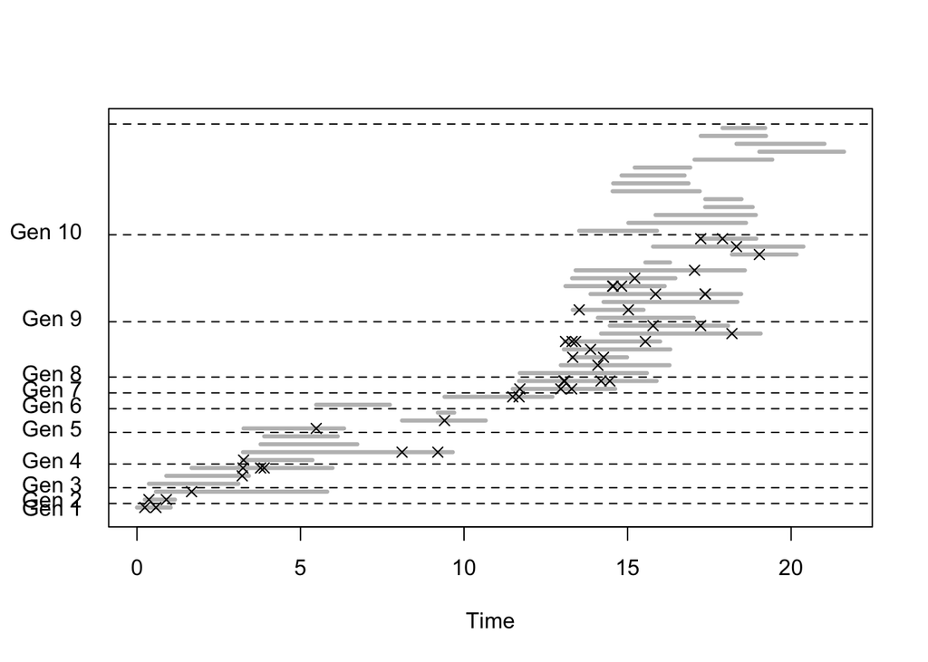

Although the visualization shown above can be helpful with showing relationships between parent and children processe, the visualization does not show the direct relationships between parent and child. Additionally, you cannot track lineage of processes without looking directly at the data output.

## Creating Custom Visualization Functions

### Refactoring genKidsV2

After going through the code provided by the author we found that by altering a few lines of code we were able to use the foundation given to us to create a new visualization. The remaining portion of this case study will go through and make adjustments to the code provided and then create a custom visualization as an alternative. To do this we start by making changes to the genKidsV function. One of the downsides as mentioned with the visualization above is that by using the genKidsV function in the current form you lose the direct relationship between parent and child. To fix this issue we added an additional variable named generation, by adding this single variable we allow ourselves the ability to capture the lineage of the newly created children processes.

```r
genKidsV = function(bTimes, cTimes, parentID, lambda = 0.75, kappa = 0.3, generation) {
  # Determine how many children each job has
  parentAge = cTimes - bTimes
  numKids = rpois(n = length(parentAge), lambda = lambda * parentAge)

  if (sum(numKids) == 0) return(NULL)

  # Determine the birth times of the children
  kidStats =
    mapply(function(n, min, max) {
      births = sort(runif(n, min, max))
      runtimes = rexp(n, rate = kappa)
      completes = rep(max, n) + runtimes
      data.frame(births, completes)
    },
    n = numKids , min = bTimes, max = cTimes,
    SIMPLIFY = FALSE)

  return(data.frame(parentID = rep(parentID, numKids),
                    kidID = 1:sum(numKids),
                    births = unlist(lapply(kidStats, "[[", "births")),
                    completes = unlist(lapply(kidStats,"[[", "completes")),
                    generation = generation

  ))
}
```

### Refactoring familyTree

After altering the genKidsV function we also had to make changes the familyTree function in order to accommodate the newly created variables. To add the new variables we added a single line of code that passes the current loop integer value of ( i ) to the create of the nextGen variable.

```r
familyTree = function(lambda = 0.5, kappa = 0.75, maxGen = 10) {
  # maxGen - maximum number of generations to observe
  # Return value - a list with 1 data frame per generation.
  allGens = vector(mode = "list", length = maxGen)

  # Generate the root of the tree
  allGens[[1]] = data.frame(parentID = NA, kidID = 1, births = 0,
                            completes = rexp(1, rate = kappa), generation = 1)

  # Generate future generations, one at a time.
  for (i in 2:maxGen) {
    nextGen = genKidsV(bTimes = allGens[[ (i - 1) ]]$births,
                       cTimes = allGens[[ (i - 1) ]]$completes,
                       parentID = allGens[[ (i - 1) ]]$kidID,
                       lambda = lambda, kappa = kappa,
                       generation = i)
    if (is.null(nextGen)) return(allGens[ 1:(i - 1) ])
    allGens[[ i ]] = nextGen
  }

  return(allGens)
}
```

### Creating createGraph Function

The createGraph function is a function creates that creates a custom visualizations and uses a number of R libraries to help with creating a decision tree like outputs for the user. Additionally, the function has two possible visualization outputs. The function can output a text view and a hierarchy view.

### Variables

- data – Data frame created by the familyTree function Type – dataFrame
- GraphType Type – string Accepted Values: text, tree, graph

### Function Elements

The createGraph function starts by first changing the list that is submitted by using the data varaibles to a dataframe named df using the rbind method.

```r
seed1 = 12062013
set.seed(seed1)
dataTree = familyTree(lambda = 0.4, kappa = .8, maxGen = 5)

df<-do.call(rbind.data.frame, dataTree)
```

```r
df$creation <- as.numeric(rownames(df))
```

```r
dfOrdered <- sqldf('select df1.creation as ParentId
          , df2.creation as kidId
          , df2.generation
          from df df1
          inner join df df2 on df1.kidId = df2.ParentId
                              and df1.generation + 1 = df2.generation')

dfOrdered$OrderBy <- as.numeric(rownames(dfOrdered))


dfOrdered$pathString <- paste(dfOrdered$ParentId,
                              dfOrdered$kidId,
                              sep = ",")
```

After the creation of the dfOrdered data frame the function then finds the maximum value of the OrderBy column and creates a new variables nRecords. This variable is then used in a for loop to help count the individual records and start the process of tracing the lineage through the generations of processes. The first step of the lineage process is to get the current generations values for the variables ParentId, kidId (Children), generation and pathString. These values are then used to query the data frame and find previous generations of Children and their corresponding parent ids. The parent ids are then stored in variable called priorValue which is stored as a comma separated list. Once the process is completed for each record and all generations are accounted for the paste function is used to concatenate the comma separated values held within the priorValue variable and create the final pathString value. This string is then updated in the dfOrdered data frame and the process starts again for the next record in the dfOrdered dataFrame. The process works its way backwards from the last memeber of the data to the first calculating each individual records lineage and saving it to the data frame.

```r
#Get Max Generations
#get Total number Records
nRecords = max(dfOrdered$OrderBy)

for(x in 0:nRecords){

      if(nRecords-x > 0){

        priorValue = NULL

        currentGen <- select(filter(dfOrdered, OrderBy == (nRecords - x)),c(ParentId,kidId, generation, pathString))

        priorValue = paste(currentGen$ParentId,currentGen$kidId, sep = ',')

        mGen = max(currentGen$generation) + 2

        if(nrow(currentGen) > 0){

            for(c in 2:currentGen$generation){

                if(c != 2){

                  searchParentId = newValue$ParentId

                }
                else{

                  searchParentId = currentGen$ParentId

                }

                searchGen = (mGen-c)-1

                newValue <- select(filter(dfOrdered, kidId == searchParentId & generation == searchGen),c(ParentId, generation))

                priorValue = paste(newValue$ParentId,priorValue,sep = ',')

          }
        }
            dfOrdered$pathString[nRecords-x] <- gsub(",","/",priorValue)
      }
    }
```

Finally, once the data set has been updated with the correct lineage the next step is to visualize the data. The function that has been created gives the user two different options when viewing the results.

### Output GraphType = Graph

The first option is shown below and is a traditional hierarchy view of the entire process. Each of the generations has its own row and each individual process is numbered in the order it was created.

[interactive chart not shown]

### Output GraphType = text

The next option is to print the results in a text view.

```
##                 levelName
## 1  Process
## 2   °--1
## 3       ¦--2
## 4       ¦   ¦--4
## 5       ¦   °--5
## 6       ¦       °--7
## 7       ¦           °--11
## 8       °--3
## 9           °--6
## 10              ¦--8
## 11              ¦   ¦--12
## 12              ¦   °--13
## 13              ¦--9
## 14              °--10
```

### Final Function

```r
createGraph = function(data, GraphType){

    df<-do.call(rbind.data.frame, data)

    df$creation <- as.numeric(rownames(df))

    dfOrdered <- sqldf('select df1.creation as ParentId
          , df2.creation as kidId
          , df2.generation
          from df df1
          inner join df df2 on df1.kidId = df2.ParentId
                              and df1.generation + 1 = df2.generation')

    dfOrdered$OrderBy <- as.numeric(rownames(dfOrdered))


    dfOrdered$pathString <- paste(dfOrdered$ParentId,
                                  dfOrdered$kidId,
                                  sep = ",")


#Get Max Generations
#get Total number Records
nRecords = max(dfOrdered$OrderBy)

for(x in 0:nRecords){

      if(nRecords-x > 0){

        priorValue = NULL

        currentGen <- select(filter(dfOrdered, OrderBy == (nRecords - x)),c(ParentId,kidId, generation, pathString))

        priorValue = paste(currentGen$ParentId,currentGen$kidId, sep = ',')

        mGen = max(currentGen$generation) + 2

        if(nrow(currentGen) > 0){

            for(c in 2:currentGen$generation){

                if(c != 2){

                  searchParentId = newValue$ParentId

                }
                else{

                  searchParentId = currentGen$ParentId

                }

                searchGen = (mGen-c)-1

                newValue <- select(filter(dfOrdered, kidId == searchParentId & generation == searchGen),c(ParentId, generation))

                priorValue = paste(newValue$ParentId,priorValue,sep = ',')

          }
        }
            dfOrdered$pathString[nRecords-x] <- gsub(",","/",priorValue)
      }
    }

    #Update Start to be Process
    dfOrdered$pathString <- paste("Process", dfOrdered$pathString, sep = '')

    tree <- as.Node(dfOrdered[,])

    if(GraphType == "text"){

      print(tree)

    }

    if(GraphType != "tree" & GraphType !="text"){

       SetGraphStyle(tree, rankdir = "TB")
      SetEdgeStyle(tree, arrowhead = "vee", color = "grey35", penwidth = 2)
      SetNodeStyle(tree, style = "filled,rounded", shape = "box", fillcolor = "red",
                   fontname = "helvetica", tooltip = GetDefaultTooltip)
      plot(tree)

    }

}
```

## Different values for the familyTree Function

```r
seed1 = 12062013
set.seed(seed1)
dataTree = familyTree(lambda = 0.4, kappa = .8, maxGen = 5)
createGraph(dataTree, "text")
```

```
##                 levelName
## 1  Process
## 2   °--1
## 3       ¦--2
## 4       ¦   ¦--4
## 5       ¦   °--5
## 6       ¦       °--7
## 7       ¦           °--11
## 8       °--3
## 9           °--6
## 10              ¦--8
## 11              ¦   ¦--12
## 12              ¦   °--13
## 13              ¦--9
## 14              °--10
```

```r
seed1 = 12062013
set.seed(seed1)
dataTree = familyTree(lambda = 0.4, kappa = .8, maxGen = 15)
createGraph(dataTree, "graph")
```

[interactive chart not shown]

## References

1. https://www.rdocumentation.org/packages/spatstat/versions/1.55-0/topics/rThomas
2. https://www.datamentor.io/r-programming/recursion
3. https://cran.r-project.org/web/packages/data.tree/vignettes/data.tree.html
4. https://cran.r-project.org/web/packages/treemap/index.html